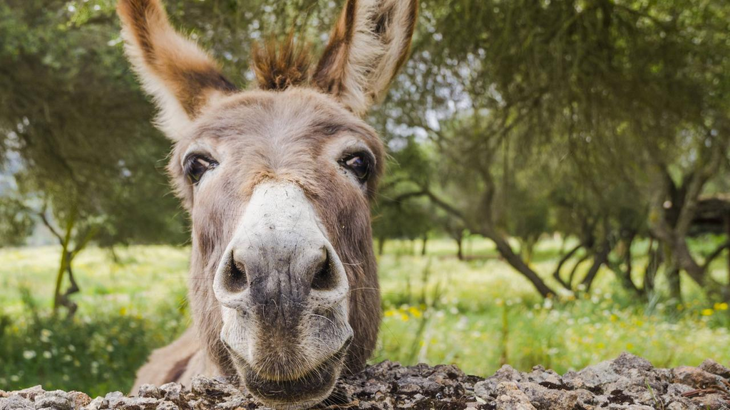

# Alles Gute!

## Der Grund

Du hast dich in letzter Zeit vor allem über zwei Dinge beschwert: Zum einen, dass du deinen **Führerschein** schon vor einer Ewigkeit gemacht hast. Du meintest, das sei ein Zeichen, dass du so langsam alt wirst. Zum anderen, dass ich mich manchmal wie ein **Esel** benehme. Also musste eine Lösung her.

## Dein Geschenk

Zu deinem Geburtstag kriegst du von uns (Herbert und mir) einen Kurs für einen Eselführerschein! Dann kannst du auch wieder beruhigt sagen, dass du erst vor kurzem deinen Führerschein gemacht hast und bist entsprechend wieder jung wie eine 20 Jährige. Zum anderen kannst du dann auch besser mit deinem Esel von Ehemann umgehen.

## Wie es abläuft

Wir beide fahren in die Nähe von Deggendorf, in den Eselhof Daxstein. Dort übernachten wir einmal in einen TinyHouse. Am nächsten morgen machen wir den Eselführerschein und freunden uns mit unseren Vierbeinern an. Anschließend gehen wir zwei, jeder mit einem eigenen Esel noch eine große Runde um den Hof.